# Automatyzacja wizualizacji danych

# Rodzaje wykresów

| Rodzaj wykresu | Funkcja |
| --- | --- |
| Wykres rozrzutu | `geom_point()` |
| Wykres liniowy | `geom_line()` |
| Wykres słupkowy | `geom_bar()` |
| Wykres pudełkowy | `geom_boxplot()` |
| Histogram | `geom_histogram()` |
| Wykres gęstości | `geom_density()` |

Listę wszystkich dostępnych typów wykresów znajdziesz w [dokumentacji](https://ggplot2.tidyverse.org/reference/index.html#geoms).

## Wykres rozrzutu

Wykres rozrzutu przedstawia związek między dwiema zmiennymi ciągłymi. Każdy punkt na wykresie przedstawia pojedynczą obserwację, przy czym oś X reprezentuje zmienną niezależną (wyjaśniającą), a oś Y zmienną zależną (modelowaną). Podstawowym zastosowaniem jest wizualne zbadanie potencjalnego związku (korelacji) między dwiema zmiennymi.

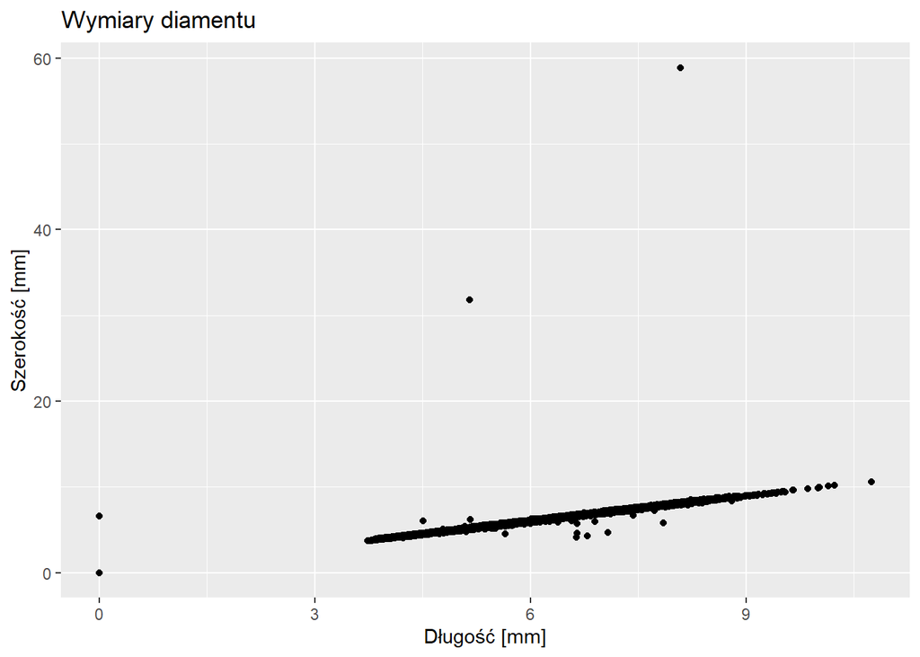

```r
ggplot(diamonds, aes(x = x, y = y)) +
  geom_point() +
  labs(title = "Wymiary diamentu",
       x = "Długość [mm]", y = "Szerokość [mm]")
```

## Wykres liniowy

Wykres liniowy jest najczęściej używany do pokazywania trendów lub zmian w czasie. Oś pozioma (X) zazwyczaj reprezentuje czas, jednak nie jest to regułą. Linie proste łączą kolejne punkty, pokazując trend lub przebieg zmian, co pomaga przedstawić, w jaki sposób zmienna zależna na osi Y zmienia się wraz ze zmienną niezależną na osi X.

Z uwagi na to, że nasz zbiór nie posiada zmiennej czasowej, to dokonamy wizualizacji średniej ceny diamentu w zależności od jego wagi. Jednakże, wagę potraktujemy jako zmienną kategoryczną z interwałem co 0,1 karata. W tym celu musimy wykonać odpowiednia obliczenia.

```r
avg_price = diamonds |>
  group_by(carat = round(carat, 1)) |>
  summarise(avg_price = mean(price)) |>
  filter(carat < 3.1)
```

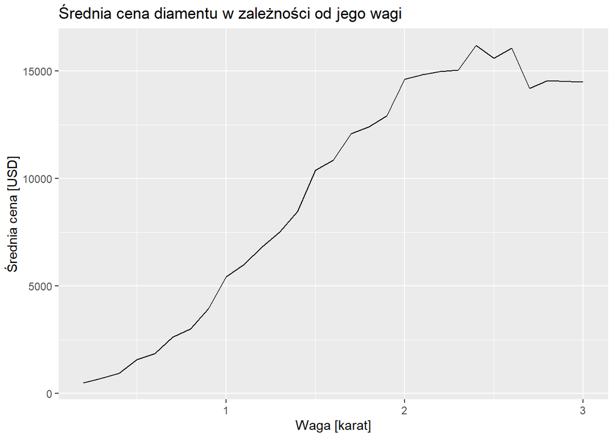

```r
ggplot(avg_price, aes(x = carat, y = avg_price)) +
  geom_line() +
  labs(title = "Średnia cena diamentu w zależności od jego wagi",
       x = "Waga [karat]", y = "Średnia cena [USD]")
```

## Wykres słupkowy

Wykres słupkowy służy do wizualnego przedstawiania danych kategorycznych za pomocą prostokątnych słupków. Wysokość lub długość słupków jest proporcjonalna do wartości, które reprezentują.

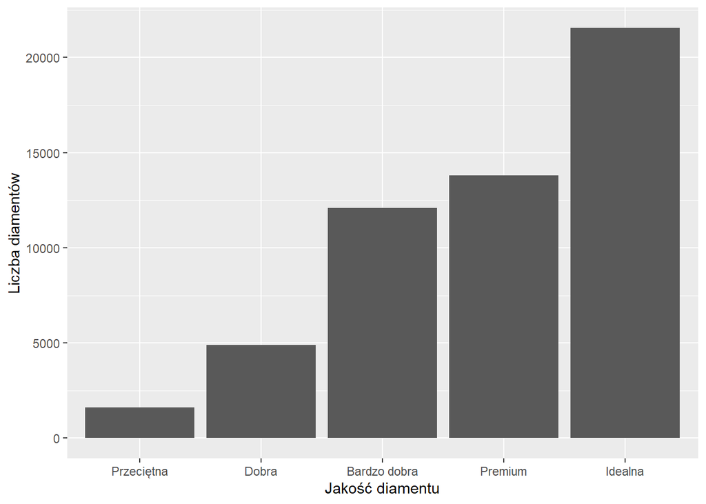

```r
cut_labels = c("Przeciętna", "Dobra", "Bardzo dobra", "Premium", "Idealna")

ggplot(diamonds, aes(x = cut)) +
  geom_bar() +
  scale_x_discrete(labels = cut_labels) +
  labs(x = "Jakość diamentu", y = "Liczba diamentów")
```

## Wykres pudełkowy

Wykres pudełkowy (nazywany również wykresem ramka-wąsy) to sposób przedstawienia rozkładu danych w oparciu o pięć następujących statystyk:

- Wartość minimalna,
- Pierwszy kwartyl (Q1, 25. percentyl),
- Mediana (Q2, 50. percentyl),
- Trzeci kwartyl (Q3, 75. percentyl),
- Wartość maksymalna.

“Pudełko” pokazuje zakres międzykwartylowy ($IQR = Q3 - Q1$), który zawiera środkowe 50% danych, natomiast “wąsy” rozciągają się od “pudełka” do najbardziej ekstremalnych punktów w zbiorze danych, które nie są klasyfikowane jako wartości odstające. Istnieje kilka sposobów definiowania długości “wąsów”, ale najbardziej standardową metodą jest ich wyznaczenie z równań: $Q3 + 1.5 \times IQR$ dla górnej części oraz $Q1 - 1.5 \times IQR$ dla dolnej części. Jeśli jakieś punkty wykraczają poza ten zakres zdefiniowany przez “wąsy”, to wtedy mamy do czynienia z wartościami odstającymi (*outliers*).

Wykresy pudełkowe wykorzystuje się przede wszystkim do porównaniu rozkładu danych w wielu grupach, oceny symetrii i rozrzutu wartości oraz wykrywania wartości odstających.

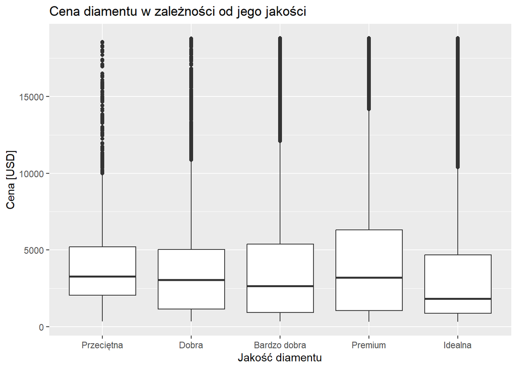

```r
ggplot(diamonds, aes(x = cut, y = price)) +
  geom_boxplot() +
  scale_x_discrete(labels = cut_labels) +
  labs(title = "Cena diamentu w zależności od jego jakości",
       x = "Jakość diamentu", y = "Cena [USD]")
```

## Histogram

Histogram, podobnie jak wykres pudełkowy, służy również do przedstawienia rozkładu danych liczbowych, z tą różnicą iż w postaci słupków. Histogram grupuje dane w przedziały (interwały) i pokazuje częstość wystąpień obserwacji mieszczących się w każdym z przedziałów. Kształt histogramu dostarcza istotnych informacji o rozkładzie danych (np. czy jest skośny czy symetryczny).

Podczas tworzenia histogramu należy wybrać odpowiednią liczbę przedziałów, ponieważ zbyt mała liczba może spowodować nadmierne uproszczenie danych (generalizację), natomiast zbyt duża liczba może spowodować zaszumienie i utrudnić interpretację.

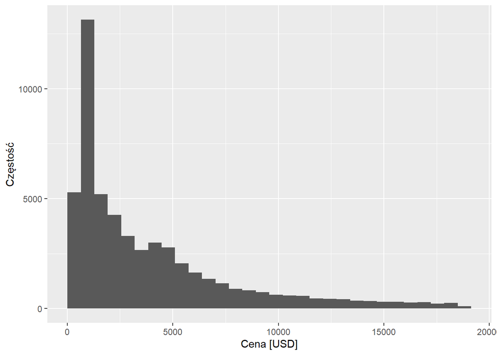

```r
ggplot(diamonds, aes(x = price)) +
  geom_histogram(bins = 30) +
  labs(x = "Cena [USD]", y = "Częstość")
```

## Wykres gęstości

Wykres gęstości to kolejna metoda wizualizacji rozkładu zmiennej ciągłej. Jest to wygładzona wersja histogramu pokazująca ciągłą krzywą zamiast dyskretnych przedziałów jak w histogramie. Oś X przedstawia wartości zmiennej wejściowej, natomiast oś Y prezentuje szacowaną gęstość prawdopodobieństwa, co pomaga zidentyfikować najczęstsze wartości w danych.

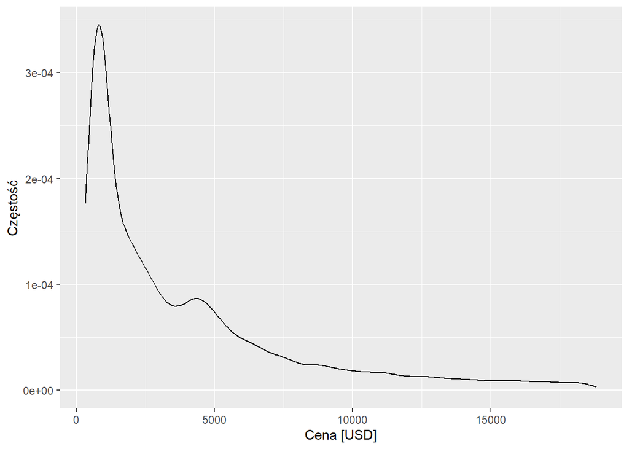

```r
ggplot(diamonds, aes(x = price)) +
  geom_density() +
  labs(x = "Cena [USD]", y = "Częstość")
```

# Ustawienia wykresów

## Modyfikacja

Aspekty wizualne wykresu można modyfikować na dwa sposoby. Pierwszy, przypisując z góry ustaloną wartość lub drugi, wykorzystując zmienną (atrybut) ze zbioru danych. Zacznijmy od zmiany koloru wszystkich punktów na niebieski.

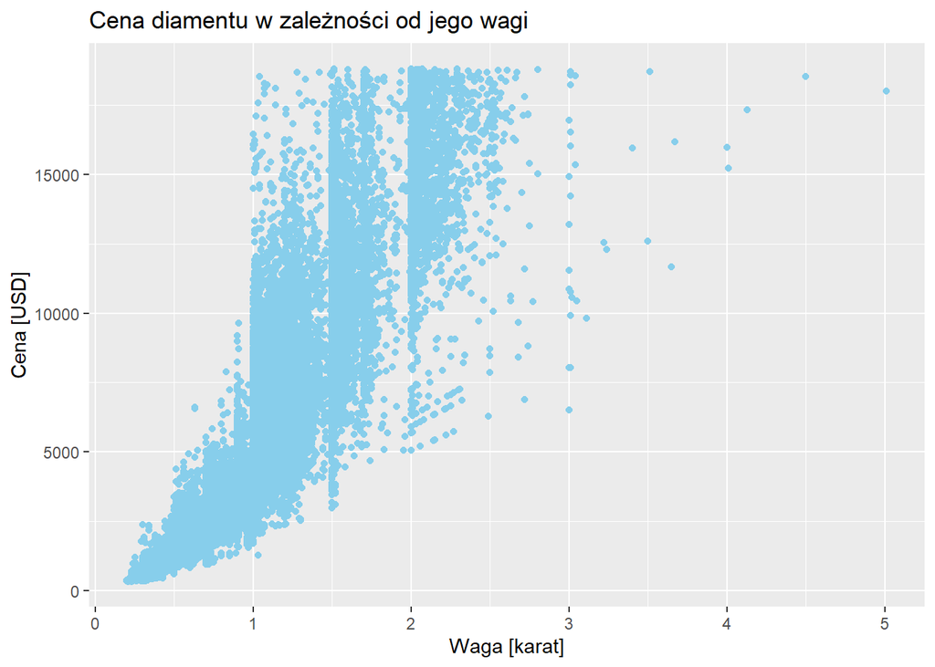

```r
ggplot(data = diamonds, aes(x = carat, y = price)) +
  geom_point(color = "skyblue") +
  labs(title = "Cena diamentu w zależności od jego wagi",
       x = "Waga [karat]", y = "Cena [USD]")
```

W drugim podejściu pokolorujmy punkty według jakości diamentu.

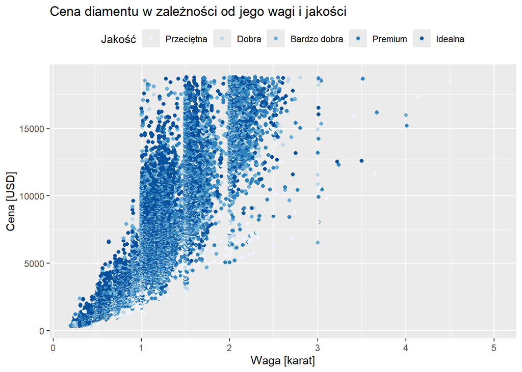

```r
ggplot(data = diamonds, aes(x = carat, y = price, color = cut)) +
  geom_point() +
  scale_colour_brewer(labels = cut_labels, palette = "Blues") +
  labs(title = "Cena diamentu w zależności od jego wagi i jakości",
       x = "Waga [karat]", y = "Cena [USD]", color = "Jakość") +
  theme(legend.position = "top")
```

Oprócz koloru (`color`) punktów i linii można zmienić wypełnienie (`fill`), rozmiar (`size`), przezroczystość (`alpha`), kształt punktów (`shape`) czy typ linii (`linetype`).

Co należy pamiętać, to że, argumenty wizualne zdefiniowane w funkcji `ggplot()` mają zastosowanie do wszystkich warstw. Natomiast argumenty zdefiniowane w określonej warstwie geometrycznej mają wpływ tylko na tę warstwę.

## Zapisywanie

Do zapisu wykresów jako pliki graficzne na dysku wykorzystuje się funkcję `ggsave()`. Domyślnie zapisuje ona ostatni wykres wyświetlony na ekranie, jednak lepiej jest wcześniej przypisać wykres do zmiennej.

```r
p = ggplot(data = diamonds, aes(x = carat, y = price)) +
  geom_point()

ggsave("diamonds.png", p)
```

Podczas zapisywania można określić dokładne wymiary (`width`, `height`, `units`) oraz rozdzielczość (`dpi`) obrazu. Obrazy można zapisać jako rastrowe (np. `.png`, `.jpg`, `.tiff`) lub wektorowe (np. `.pdf`, `.svg`). Zazwyczaj preferowane są formaty wektorowe, ponieważ nie tracą one ostrości przy powiększaniu.

```r
ggsave("diamonds.pdf", p, width = 6, height = 4, units = "in", dpi = 300)
```